# Flexibilidad del Modelado Bayesiano con Stan: Heterocedasticidad

## 1 Introducción

Este ejemplo muestra cómo el enfoque bayesiano con Stan permite ajustar modelos flexibles que serían difíciles o imposibles de estimar con métodos clásicos. En particular, consideramos un modelo en el que tanto la **media como la varianza** del salario dependen del nivel educativo.

## 2 Simulación de Datos con Heterocedasticidad

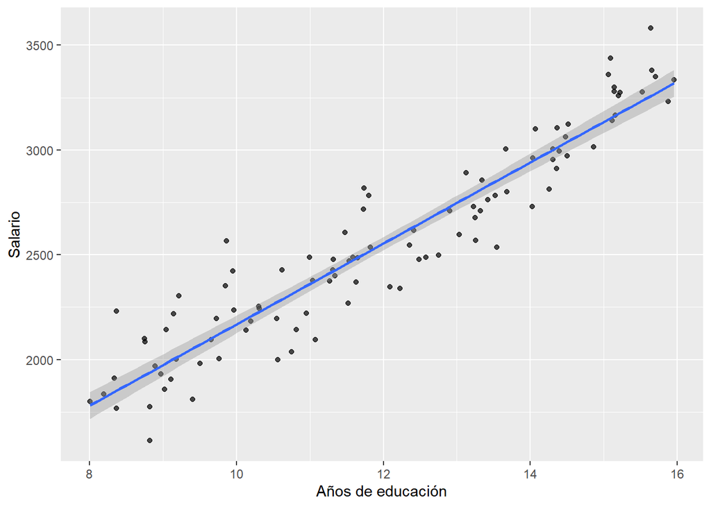

```r
ggplot(data, aes(x = educ, y = wage)) +
  geom_point(alpha = 0.7) +
  geom_smooth(method = "lm") +
  labs(x = "Años de educación", y = "Salario")
```

## 3 Modelo Bayesiano: Media y Varianza Dependientes de Educación

Modelo completo:

$$\begin{aligned}
\log(wage_i) &\sim \mathcal{N}(\mu_i, \sigma_i^2) \\
\mu_i &= \alpha + \beta \cdot educ_i \\
\log(\sigma_i) &= \gamma_0 + \gamma_1 \cdot educ_i
\end{aligned}$$

Distribuciones a priori e interpretación

- **$\alpha \sim \mathcal{N}(7,\ 2^2)$**  
  Representa el log-salario esperado para una persona con **cero años de educación**.  
  Esta prior es *débilmente informativa*, con alta incertidumbre.  
  $\exp(7) \approx 1096$, por lo que se espera que el salario base esté alrededor de $1000, pero puede variar ampliamente.
- **$\beta \sim \mathcal{N}(0.08,\ 0.05^2)$**
  Representa el **retorno salarial por cada año adicional de educación** (en escala log).
  En términos salariales, esto implica:
  $$\exp(0.08) \approx 1.083$$
  Es decir, se espera un incremento promedio de aproximadamente **8.3% por año adicional de educación**, coherente con estimaciones empíricas en la literatura económica.
- **$\gamma_0 \sim \mathcal{N}(-1,\ 1^2)$**
  Controla el nivel base de la **desviación estándar** del log-salario.
  $$\exp(-1) \approx 0.37$$
  Es decir, se espera que la dispersión salarial base sea moderada, pero se permite cierta flexibilidad.
- **$\gamma_1 \sim \mathcal{N}(0,\ 0.2^2)$**  
  Captura cómo cambia la **desviación estándar** del log-salario con la educación.  
  Un valor **negativo** implica que, a mayor educación, hay **menor incertidumbre salarial** (más estabilidad).  
  Un valor **positivo** indica lo contrario: mayor educación → más dispersión.

Estas priors combinan conocimiento empírico con flexibilidad, permitiendo un modelo robusto y realista, especialmente útil cuando el tamaño muestral es reducido o hay colinealidad en los datos.

## 4 Código del Modelo en Stan

```r
stan_code <- "
data {
  int<lower=0> N;
  vector[N] log_wage;
  vector[N] educ;
}
parameters {
  real alpha;
  real beta;
  real gamma_0;
  real gamma_1;
}
model {
  alpha ~ normal(7, 2);
  beta ~ normal(0.08, 0.05);
  gamma_0 ~ normal(-1, 1);
  gamma_1 ~ normal(0, 0.2);

  for (i in 1:N) {
    log_wage[i] ~ normal(alpha + beta * educ[i], exp(gamma_0 + gamma_1 * educ[i]));
  }
}
generated quantities {
  vector[N] sigma;
  for (i in 1:N) {
    sigma[i] = exp(gamma_0 + gamma_1 * educ[i]);
  }
}
"
```

## 5 Ajuste del Modelo

```r
stan_data <- list(N = N, log_wage = data$log_wage, educ = data$educ)
model <- cmdstan_model(write_stan_file(stan_code), cpp_options = list(stan_threads = TRUE))
fit <- model$sample(
  data = stan_data,
  chains = 4,
  parallel_chains = 4,
  threads_per_chain = 2,
  iter_sampling = 2000,
  iter_warmup = 500,
  seed = 123
)
```

[output not shown]

[output not shown]

[output not shown]

[output not shown]

[output not shown]

```
## Chain 2
```

[output not shown]

[output not shown]

[output not shown]

[output not shown]

```
## Chain 2
```

[output not shown]

[output not shown]

[output not shown]

[output not shown]

```
## Chain 2
```

[output not shown]

[output not shown]

[output not shown]

[output not shown]

```
## Chain 2
```

[output not shown]

[output not shown]

[output not shown]

[output not shown]

```
## Chain 2
```

[output not shown]

[output cut: 53 more lines]

[output not shown]

```r
fit$print(variables = c("alpha", "beta", "gamma_0", "gamma_1"))
```

```
##  variable  mean median   sd  mad    q5   q95 rhat ess_bulk ess_tail
##   alpha    6.90   6.90 0.04 0.04  6.84  6.96 1.00     2654     3126
##   beta     0.08   0.08 0.00 0.00  0.07  0.08 1.00     2760     3296
##   gamma_0 -1.12  -1.12 0.36 0.36 -1.71 -0.52 1.00     2038     2268
##   gamma_1 -0.14  -0.14 0.03 0.03 -0.19 -0.09 1.00     2043     2215
```

## 6 Visualización: Varianza Estimada vs. Real

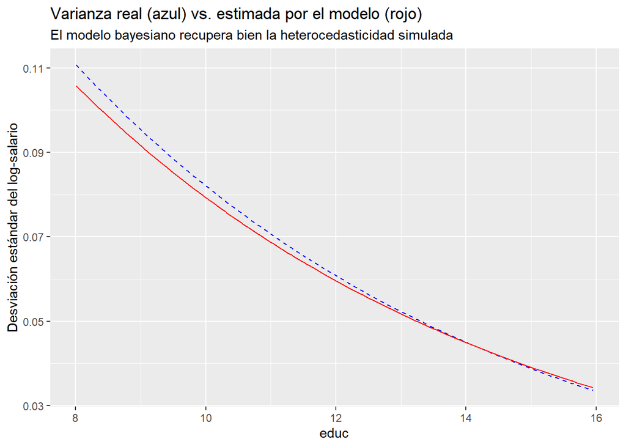

```r
sigma_draws <- fit$draws(variables = "sigma", format = "df")
sigma_post_mean <- sigma_draws %>% select(starts_with("sigma")) %>% colMeans()
data$sigma_post <- sigma_post_mean

ggplot(data, aes(x = educ)) +
  geom_line(aes(y = sigma), color = "blue", linetype = "dashed") +
  geom_line(aes(y = sigma_post), color = "red") +
  labs(y = "Desviación estándar del log-salario",
       title = "Varianza real (azul) vs. estimada por el modelo (rojo)",
       subtitle = "El modelo bayesiano recupera bien la heterocedasticidad simulada")
```

**Interpretación:** El gráfico muestra cómo el modelo bayesiano logra estimar correctamente que la varianza del salario disminuye con la educación, acercándose mucho a los valores simulados (línea azul). La línea roja representa el valor posterior medio estimado.

## 7 Comparación con Modelo Clásico

```r
lm_fit <- lm(log(wage) ~ educ, data = data)
summary(lm_fit)
```

```
##
## Call:
## lm(formula = log(wage) ~ educ, data = data)
##
## Residuals:
##       Min        1Q    Median        3Q       Max
## -0.200413 -0.037654 -0.002767  0.032065  0.184596
##
## Coefficients:
##             Estimate Std. Error t value Pr(>|t|)
## (Intercept)  6.91286    0.03502  197.40   <2e-16 ***
## educ         0.07631    0.00287   26.59   <2e-16 ***
## ---
## Signif. codes:  0 '***' 0.001 '**' 0.01 '*' 0.05 '.' 0.1 ' ' 1
##
## Residual standard error: 0.06511 on 98 degrees of freedom
## Multiple R-squared:  0.8782, Adjusted R-squared:  0.877
## F-statistic: 706.8 on 1 and 98 DF,  p-value: < 2.2e-16
```

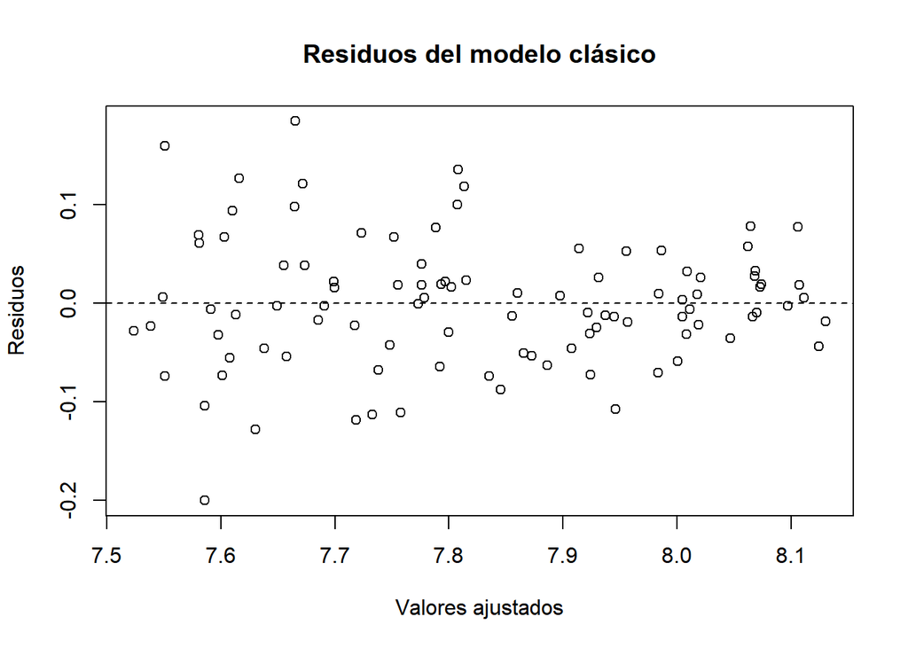

```r
plot(lm_fit$fitted.values, resid(lm_fit),
     xlab = "Valores ajustados", ylab = "Residuos",
     main = "Residuos del modelo clásico")
abline(h = 0, lty = 2)
```

**Interpretación:** El modelo clásico `lm()` asume varianza constante. En el gráfico de residuos se puede observar que, para niveles bajos de educación, los residuos tienden a ser más dispersos, lo que indica **heterocedasticidad no capturada** por el modelo clásico. Esto muestra una limitación importante frente a la flexibilidad del enfoque bayesiano.

## 8 Discusión

- El modelo clásico asume varianza constante y no puede capturar la heterocedasticidad.
- El modelo bayesiano con Stan permite modelar la varianza como función de la educación.
- ¿Qué otros contextos económicos podrían beneficiarse de esta flexibilidad?